**Temperature Data**

As mentioned in *Data Collection*, many temperature values just weren’t possible, or missing.  
We’ll start with addressing the **missing values**:

- Rows with *NA* max temp values
- Rows with *NA* min temp values
- Rows with *NA* max and min temp values

```r
# Filter out the NA values
data.max.na <- pre_data %>%
  filter(!is.na(min_temp_mean),
         is.na(max_temp_mean))

data.min.na <- pre_data %>%
  filter(is.na(min_temp_mean),
         !is.na(max_temp_mean))

print(paste("There are", nrow(data.max.na), "missing max temp values"))
```

```
## [1] "There are 64 missing max temp values"
```

```r
print(paste("There are", nrow(data.min.na), "missing min temp values"))
```

```
## [1] "There are 50 missing min temp values"
```

```r
print(paste("The entire data set has", nrow(pre_data), "rows"))
```

```
## [1] "The entire data set has 75087 rows"
```

But even once I subsetted the datasets into whether they had missing max or min temp values, those datasets also had erroneous values. For the dataset where **min temp** was **NA**, there was some bad corresponding **max temp** values. You can see this is the following graphic. Keep in mind that each dot does not represent a daily value, but rather a 15 day mean.

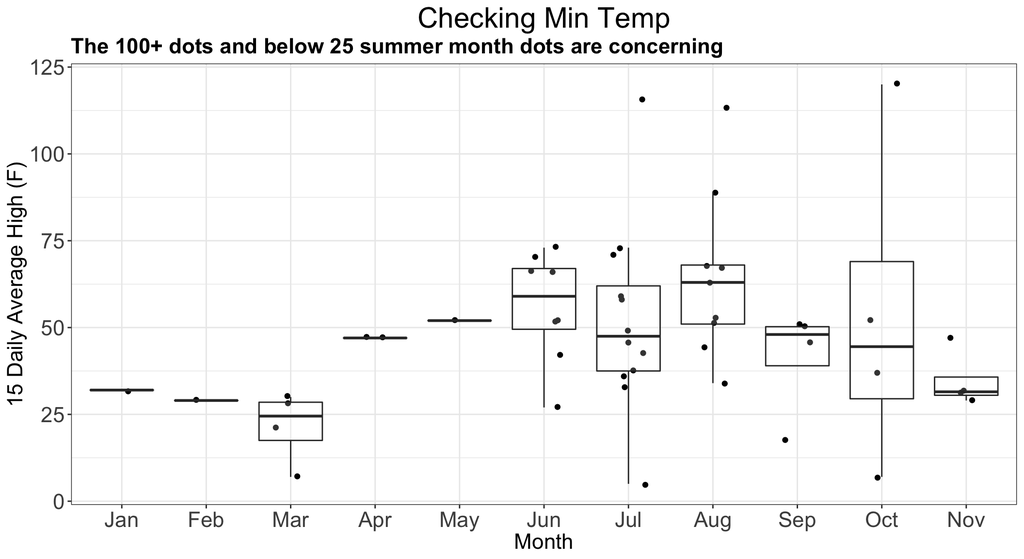

To fix this problem, I decided to make every **max temp** value that didn’t seem right, into a **NA** value. That is: *if the values was above 100, or below 40 between June and October (for a 15 day period), then make it NA*. This made both **max** and **min** temps **NA**, so I binded those in with and existing dataset where both **max** and **min** were also **NA.**

```r
# turning bad values in NA
data.min.na.2 <- data.min.na %>%
  mutate(season = case_when(
    month(date) > 5 & month(date) < 11 ~ "summer",
    TRUE ~ "other"),
    temp = case_when(
      max_temp_mean > 100 ~ NA_integer_,
      max_temp_mean < 40 & season == "summer" ~ NA_integer_,
      TRUE ~ max_temp_mean),
    max_temp_mean = temp) %>%
  select(-c(season, temp))

# filter out NA to add to both.na
bad.min <- data.min.na.2 %>% filter(is.na(max_temp_mean))

# both are NA
data.both.na <- pre_data %>%
  filter(is.na(max_temp_mean),
         is.na(min_temp_mean)) %>%
  rbind(bad.min) # add recently changed --> NA
```

Now here is a good time to mention that this analysis left me with a necessity to make artbitrary decisions when there wasn’t a clear answer. *How do we know which temperature values are badly reported/observed? Maybe they are outliers?*  
I will explain gradually some of the decisions I made to combat this problem, and I don’t offer them as end-all solutions *(I’m not sure any exist)*, but possible solutions that seemed to work.

For the dataset where the **max temps** are **NA** values, I checked the **min temp** values, found nothing too unusual, and decided to leave it alone.

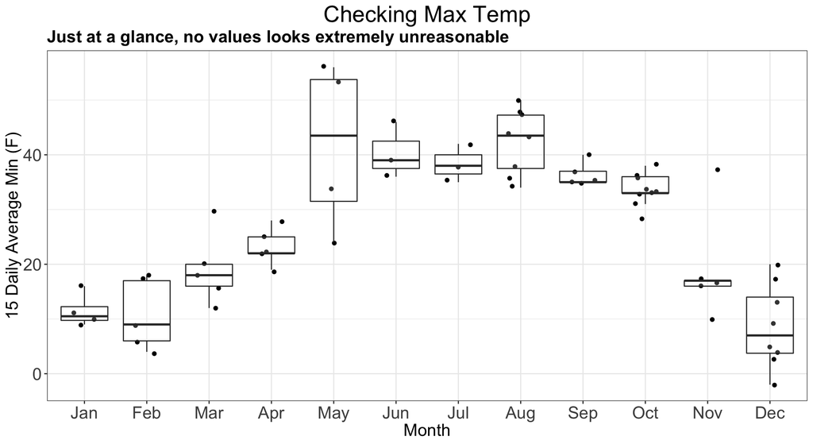

Exploring further, I found another **peculiarity:** a large amount of observations where both the **max** and **min** were **32**. The following visualization maps that, using the **average temperature** between the **max** and **min** values as the Y. You can tell it’s an anomaly, because of it’s grouping so far outside of the spread of the data. The spread of the 25-75% range of the data, represented by the box, is very small. For summer months, the anamoly lies near the far 1% of the data.

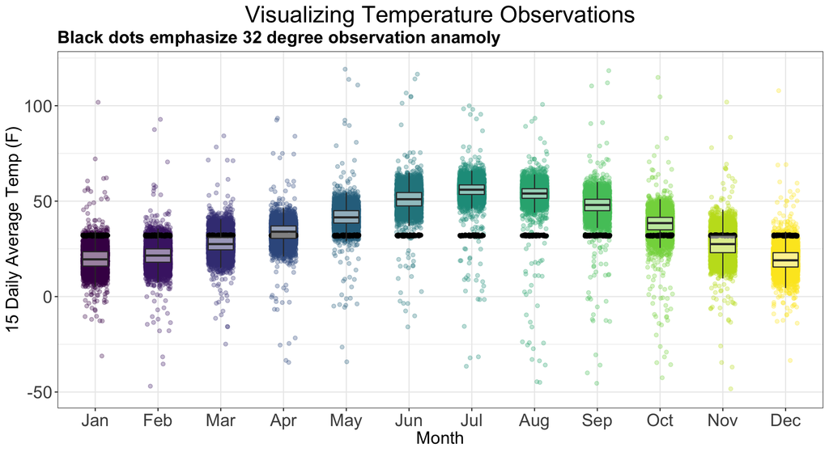

Just like the **NA** data, I subsetted out the **32 degree anamolies** from the *regular data*.

```r
# subset 32 degree avg temperatures: 922 Rows
data.32 <- data.2 %>%
  filter(max_temp_mean == 32 & min_temp_mean == 32)

# take the compliment of the above
data.3 <- data.2 %>%
  filter(max_temp_mean != 32 | min_temp_mean != 32)
```

After doing all of that subsetting, the *regular data* now has **67022** or the original **75,087** rows. With those rows, I found some more data peculiarities through visualizations, that led me to more data wrangling and cleaning.  
After glancing at the data, I realized that some of the temperature recorded were either not possible, or did not make sense for the month they were recorded in. To visualize this, I decided take the **top and bottom .8%** for **max** and the **top .8% and bottom 1.6%** of the **min** columns, and graph them against the rest. Ultimately, I wanted to see where I draw the line to what I thought was **unlikely data**.  
Here are the **max** and **min visualizations** made.

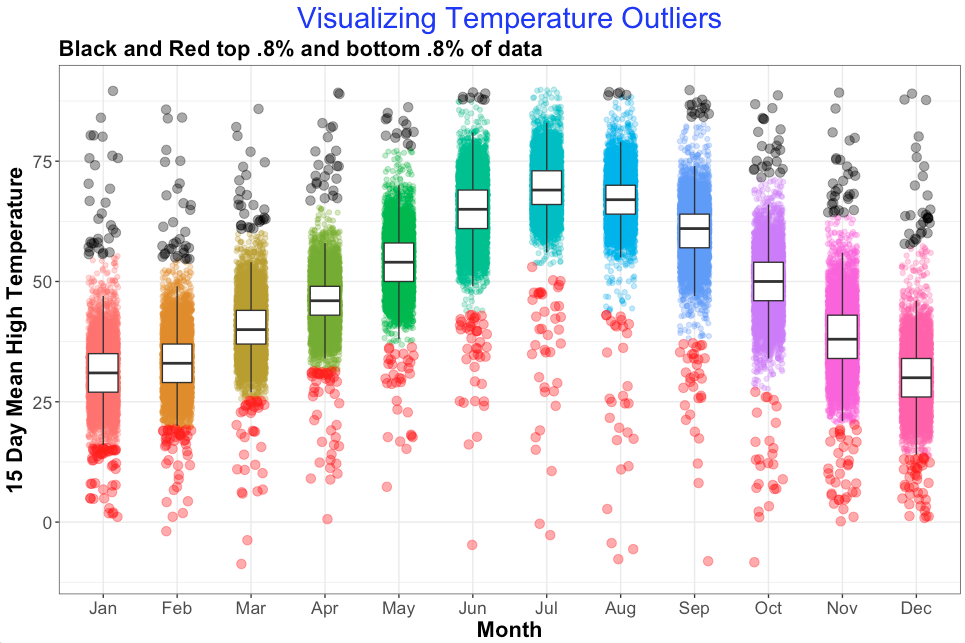

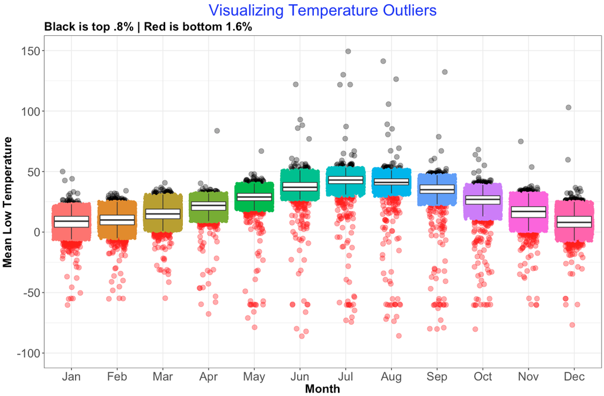

By looking at the **red** and **black** dots, the very improbable observations are seen. From here, I decided to impute those values.  
Here’s a review of what you’ve read.

- Subsetted rows with *NA* max temp values
- Subsetted rows with *NA* min temp values
- Out of those, turned improbable values into *NA*
- Subsetted rows with *NA* max and min temp values
- Subsetted rows with possibly programmed *32 degree* values
- Subsetted top and bottom .8% of max temp values
- Subsetted top .8% and bottom 1.6% of min temp values
- All **NA** values will be re-estimated
- [Full Code](https://github.com/Roctober92/senior_project_scripts/blob/master/data_prep/na_tempdata_analysis.R)